# Trends in giant kelp nitrogen surge uptake

Erin Ansbro, Cara Kuuskvere, Tani Valdez Rivas

December 2023

# Rationale and Research Questions

Kelp forests along the United States West Coast are impacted by increasing temperatures as a result of climate change. Since the late 19th century, Santa Barbara County in Southern California has had an increase in average temperature by 4.1 degrees Fahrenheit (Wilson, 2019). Kelp not only provides a healthy ecosystem for other flora and fauna but also provides ecosystem services to humans as well. Kelp assists with human-related environmental issues in two ways. First, kelp can sequester a large amount of carbon, aiding in climate change mitigation (Hurlimann, 2019). Secondly, they absorb excess nitrogen, which can lessen the impacts of agricultural runoff (Conroy, 2023). A recent study has shown that increased nitrogen uptake by kelp can limit the effect that heat has on them. This is an interesting development because nitrogen and eutrophication are generally seen as negative consequences of human interference. However, in this case, it could assist kelp and help them survive increased climate-change-related temperature increases (Fernández, 2020). Interested in this recent research, data about nitrogen concentration amount and uptake were located in the Long-Term Ecological Research database titled “SBC LTER: Reef: Surge uptake capability in Macrocystis pyrifera in response to pulses of three different forms of nitrogen” (Cedeno, 2021) and ” SBC LTER: Reef: Macrocystis pyrifera CHN content (carbon, hydrogen, nitrogen), ongoing since 2002” (Santa Barbara, 2021). This data looked simple enough to clean and manipulate, while also providing enough information for a research project.

We are interested in trends in giant kelp nitrogen concentration amount and nitrogen surge uptake. Specific questions include: 1. Has nitrogen concentration in kelp changed over the years (2002-2021)? 2. Does giant kelp nitrogen concentration amount vary by season? 3. Does nitrogen surge uptake vary between the spring and summer seasons? 4. Does giant kelp nitrogen surge uptake vary based on the amount of exposure? 5. Does uptake vary by type of nitrogen (ammonium, nitrate, and urea)?

Github Information: https://github.com/Tani-ValdezRivas/ValdezKuuskvereAnsbro

# Dataset Information

Data sets were found on the Environmental Data Initiative. All sets were from the Santa Barbara Coastal Long Term Ecological Research Site (SBC LTER) which is based within the University of California, Santa Barbara (UCSB) Marine Science Institute, and is part of the National Science Foundation’s LTER Network.

The first data set focuses on one experiment done that examines nitrogen and biomass uptake by kelp during timed nitrogen blasting. The first data set was used to determine if nitrogen uptake varies by time (minutes), season, or nitrogen type. The second data set has dates and percent nitrogen of kelp over almost a twenty year period. This second data set was used to gain a general sense of nitrogen found in kelp in Santa Barbara, CA and to see if that has changed over time.

:Data Set Information

| Detail | Data Set 1 | Data Set 2 |
| --- | --- | --- |
| Source | Santa Barbara Coastal Long Term Ecological Research (LTER) | Santa Barbara Coastal Long Term Ecological Research (LTER) |
| Retrieved from | https://portal.edirepository.org/nis/mapbrowse?packageid=edi.1022.2 | https://sbclter.msi.ucsb.edu/data/catalog/package/?package=knb-lter-sbc.24 |
| Variables Used | Nitrogen Types, Season, Day Replicate, Time, Blade Replicate, Uptake Rate, Biomass Uptake Rate | Year, Month, Date, Nitrogen Percent |
| Date | 2021 | 2002-2021 |

# Exploratory Analysis

A map was created to gain a sense of location. The Map shows the sampling sites of nitrogen uptake along the coast of California.

[interactive chart not shown]

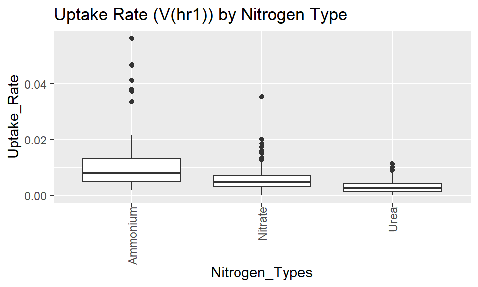

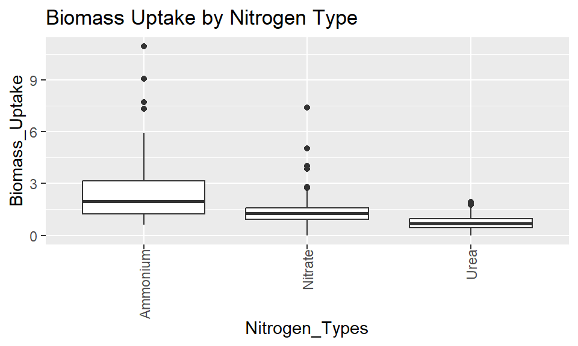

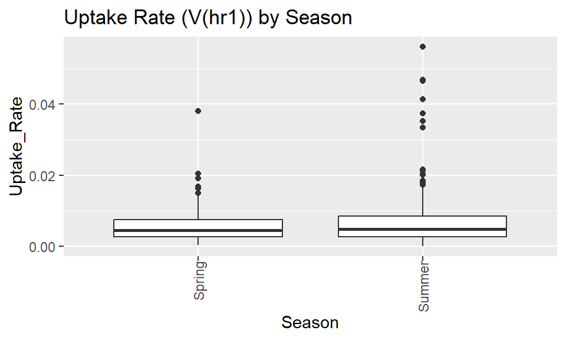

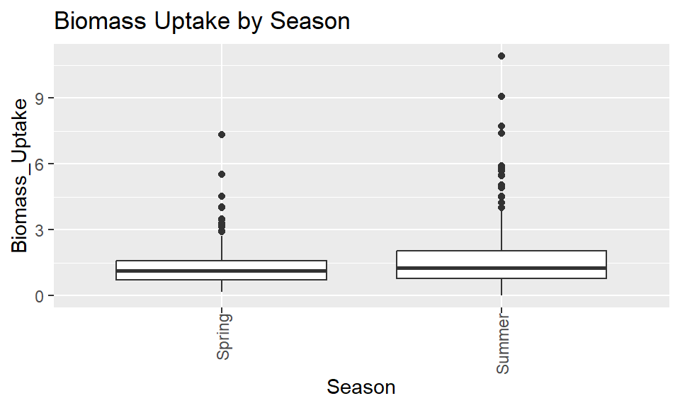

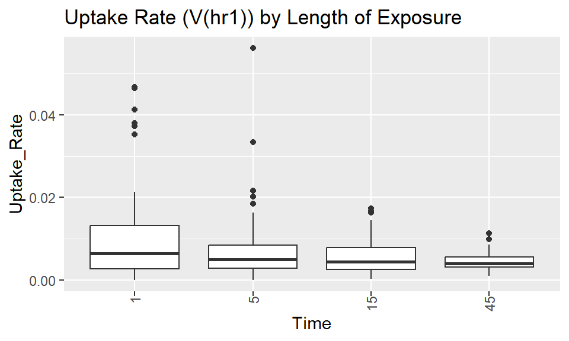

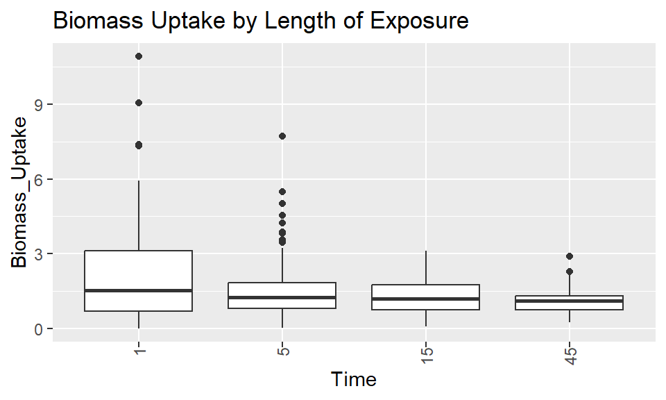

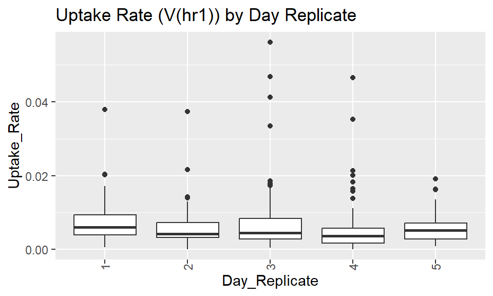

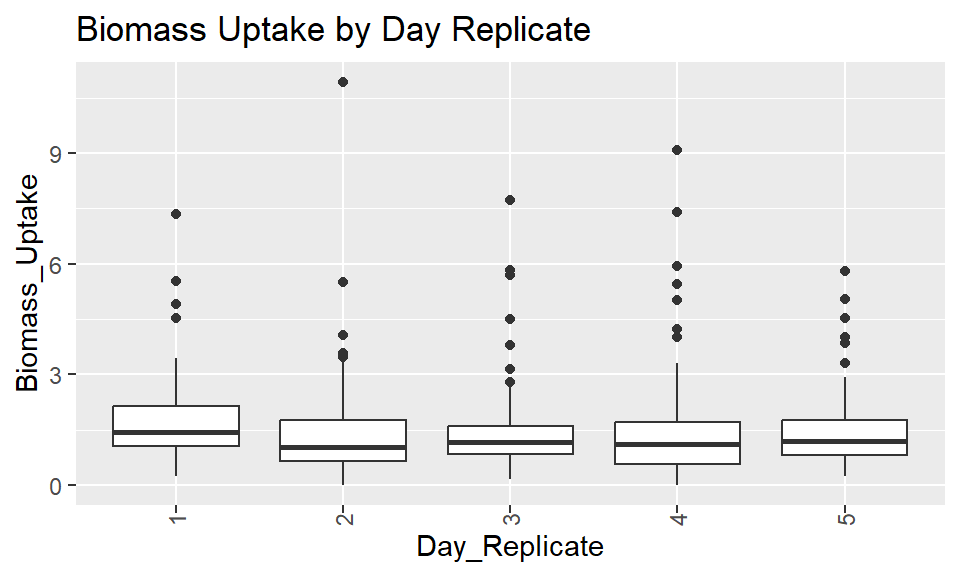

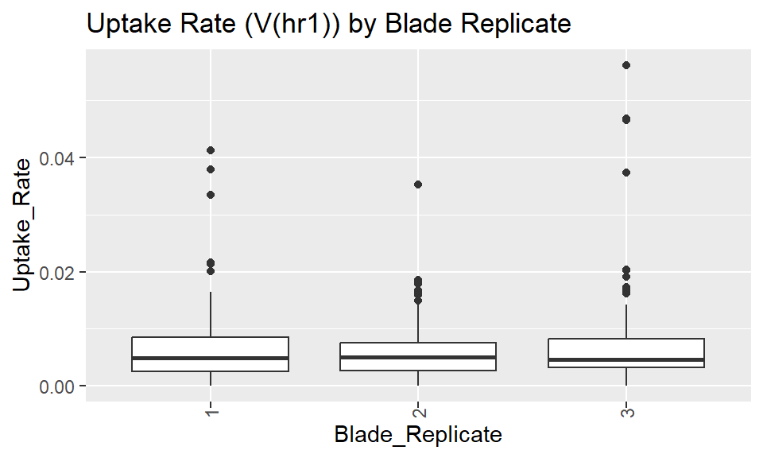

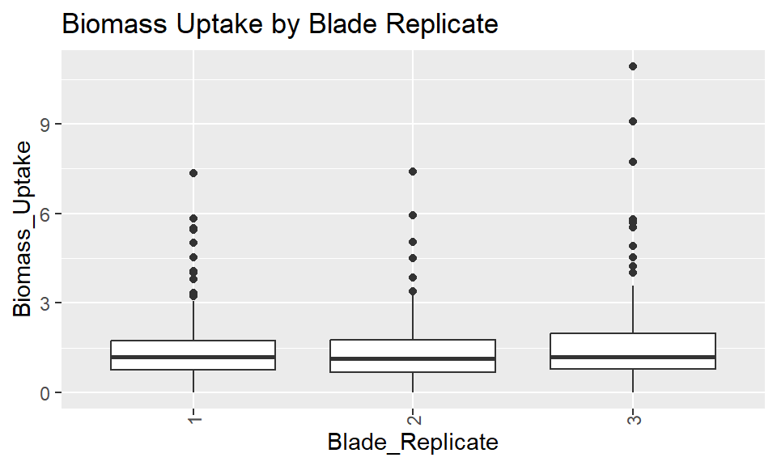

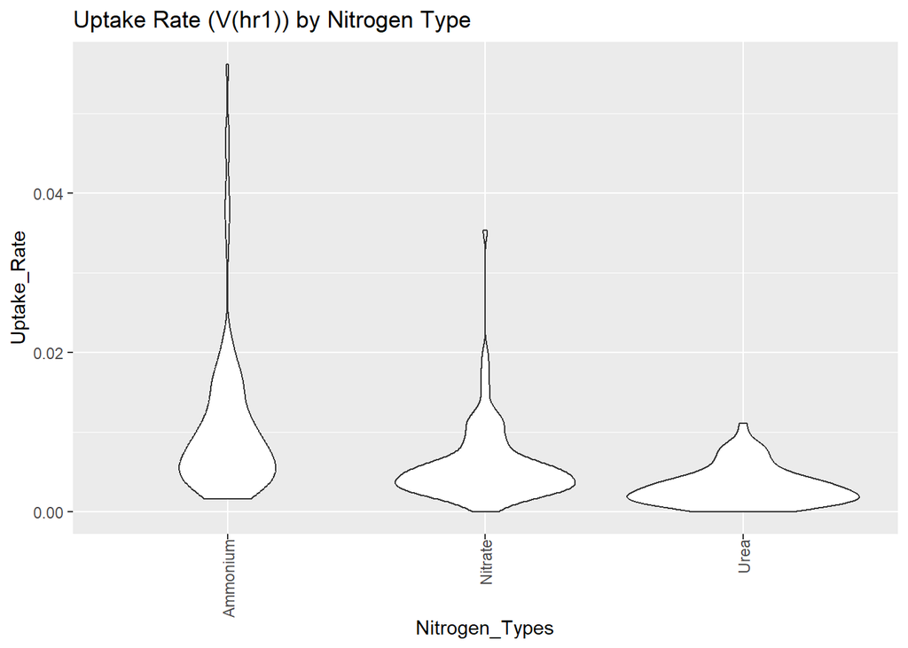

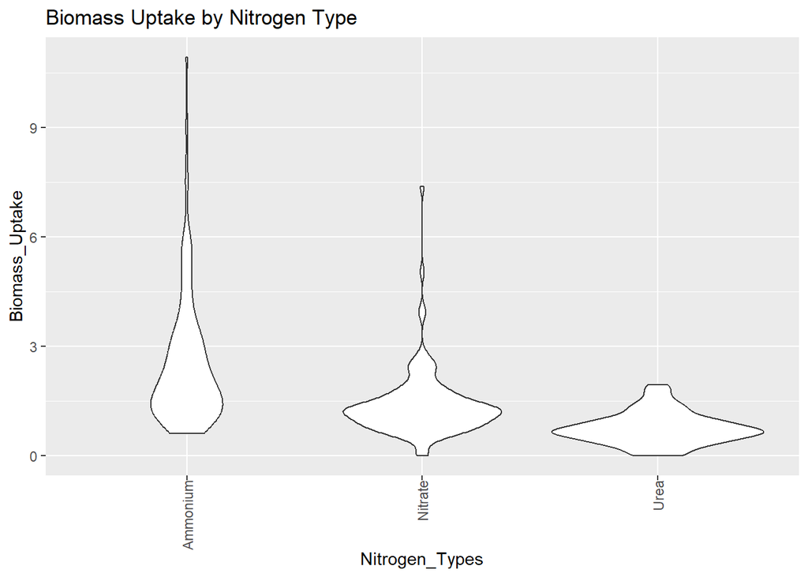

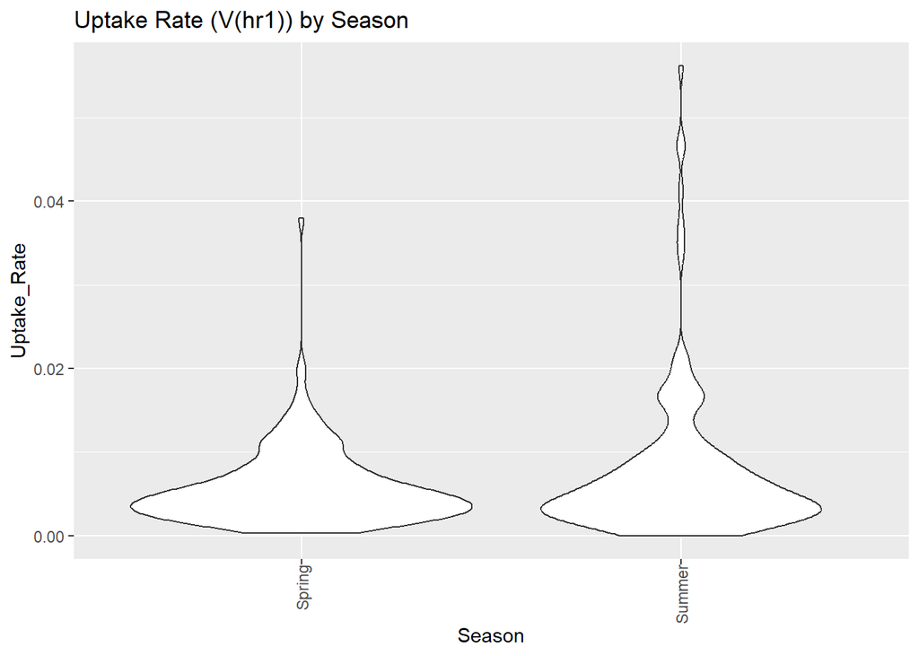

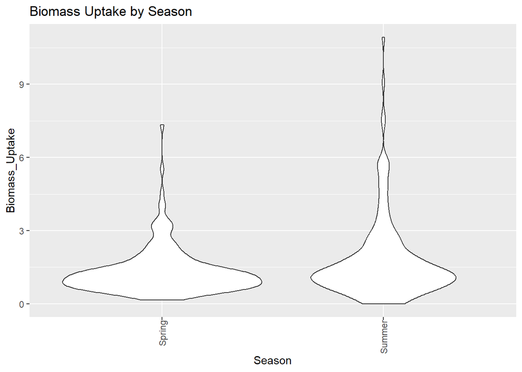

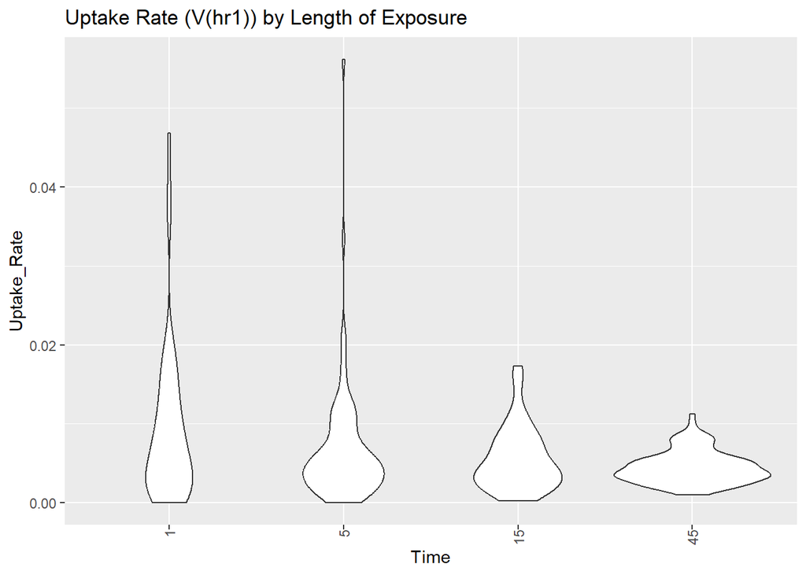

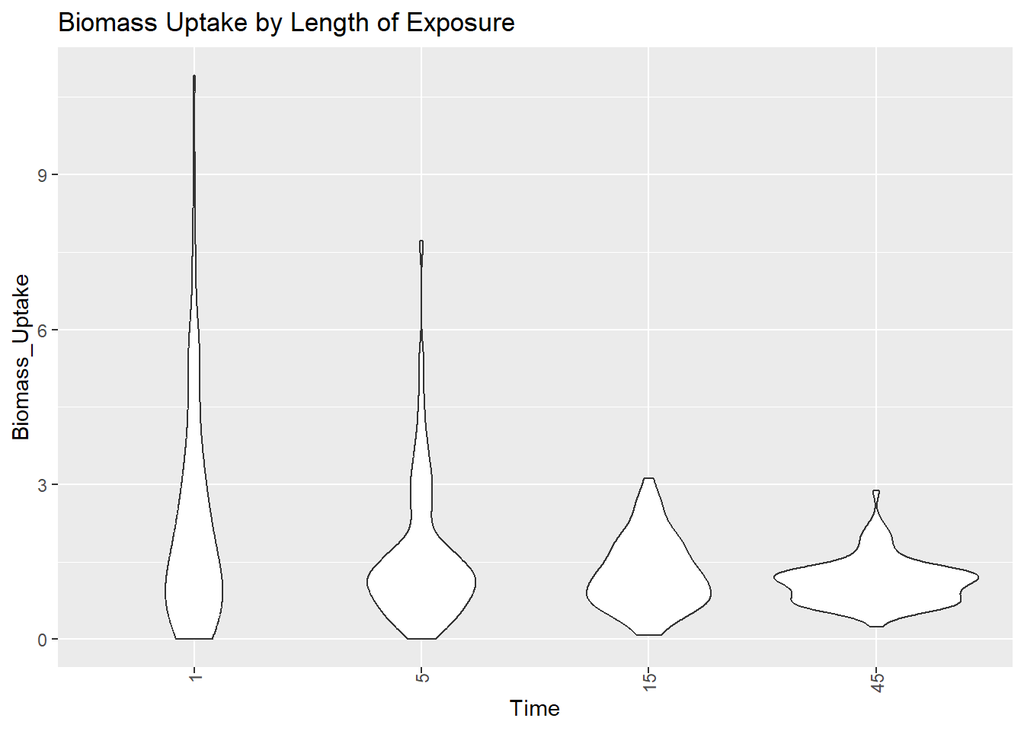

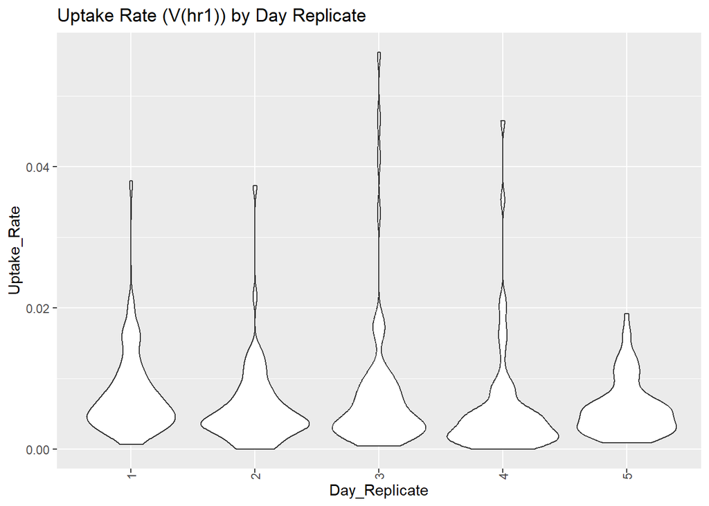

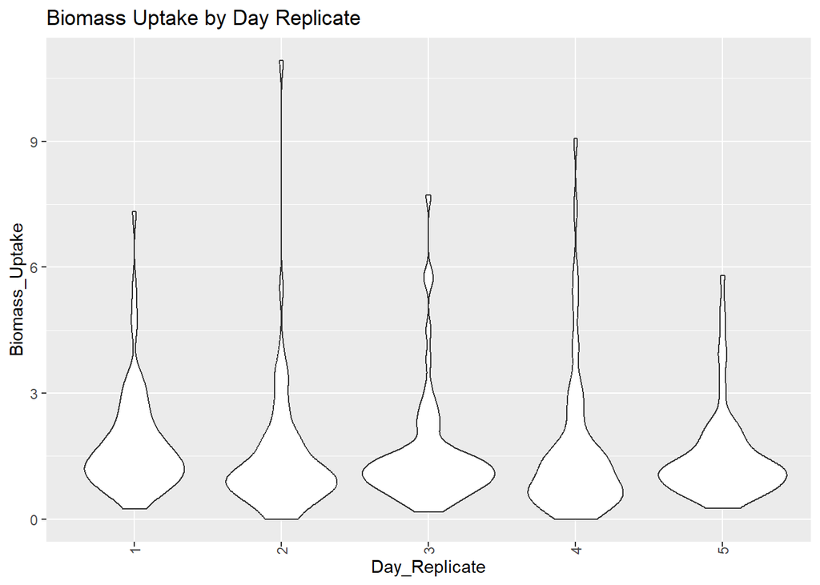

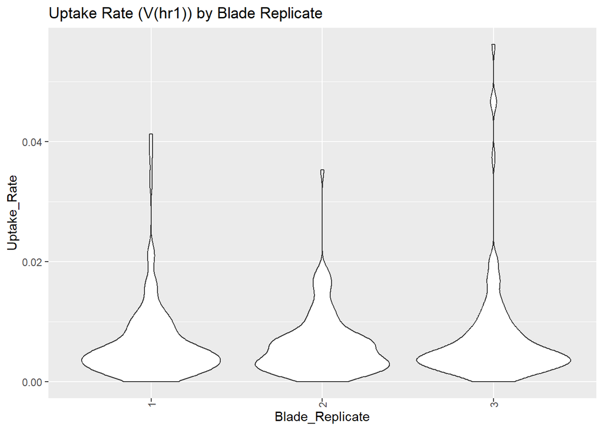

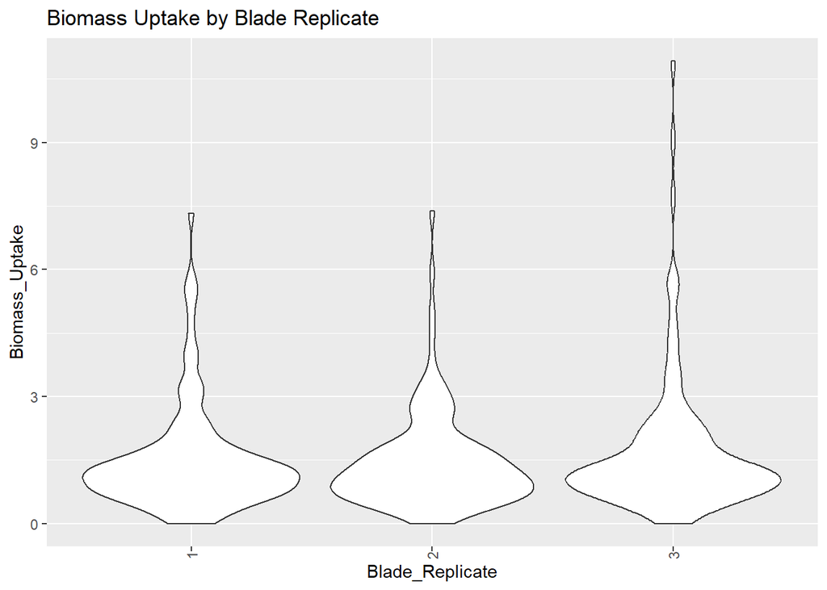

The last part of the exploratory analysis focused on an overview of nitrogen concentration amount over the last twenty years. A summary was used on the entire data set as well as on the nitrogen concentration column to gain a general sense of what amounts were present.

```
##        X          Sample_Number        Year          Month
##  Min.   :   3.0   Min.   :  1.0   Min.   :2002   Min.   : 1.000
##  1st Qu.: 337.2   1st Qu.:176.0   1st Qu.:2006   1st Qu.: 4.000
##  Median : 665.5   Median :352.0   Median :2011   Median : 7.000
##  Mean   : 671.5   Mean   :352.1   Mean   :2011   Mean   : 6.602
##  3rd Qu.:1007.8   3rd Qu.:513.0   3rd Qu.:2016   3rd Qu.:10.000
##  Max.   :1334.0   Max.   :910.0   Max.   :2021   Max.   :12.000
##
##          Date         Site     Number_of_Samples Sample_Replicate
##  2014-03-12:   6   ABUR :434   Min.   : 8.00     Min.   :1.0
##  2003-01-16:   4   ABUR :  2   1st Qu.:15.00     1st Qu.:1.0
##  2003-02-18:   4   AQUE :410   Median :15.00     Median :1.5
##  2003-03-05:   4   MOHK :436   Mean   :14.67     Mean   :1.5
##  2007-01-03:   4               3rd Qu.:15.00     3rd Qu.:2.0
##  2007-02-06:   4               Max.   :16.00     Max.   :2.0
##  (Other)   :1256
##    Wet_Weight          Dry_Weight        Ratio_Dry_to_Wet
##  Min.   :-99999.00   Min.   :-99999.00   Min.   :-99999.00
##  1st Qu.:     5.88   1st Qu.:     0.48   1st Qu.:     0.07
##  Median :     7.02   Median :     0.66   Median :     0.09
##  Mean   :  -616.79   Mean   :  -779.33   Mean   :  -779.93
##  3rd Qu.:     8.53   3rd Qu.:     0.86   3rd Qu.:     0.11
##  Max.   :    17.19   Max.   :     2.79   Max.   :     0.38
##
##  Analytical_Dry_Weight Carbon_Percent  Hydrogen_Percent    Nitrogen_Percent
##  Min.   :1797          Min.   :20.25   Min.   :-99999.00   Min.   :0.097
##  1st Qu.:2155          1st Qu.:28.39   1st Qu.:     4.01   1st Qu.:1.570
##  Median :2310          Median :31.33   Median :     4.72   Median :2.063
##  Mean   :2394          Mean   :32.17   Mean   : -4675.62   Mean   :2.174
##  3rd Qu.:2517          3rd Qu.:35.27   3rd Qu.:     5.27   3rd Qu.:2.710
##  Max.   :4770          Max.   :44.52   Max.   :     7.57   Max.   :4.360
##
##  Carbon_Nitrogen_Ratio
##  Min.   : 6.64
##  1st Qu.:11.43
##  Median :14.94
##  Mean   :16.89
##  3rd Qu.:20.86
##  Max.   :48.16
##
##                                                         Notes
##                                                            :1247
##  dry_wet ratio very large, possible processing error       :   6
##  reproducibility and replicate data noisy.  Will reanalyze.:   6
##  missing dry wt                                            :   4
##  used average of individual plants                         :   4
##  Average of 10 composite samples                           :   2
##  (Other)                                                   :  13
##            NewSites
##  Arroyo Burro  :436
##  Arroyo Quemado:410
##  Mohawk        :436
##
##
##
##
```

```
##    Min. 1st Qu.  Median    Mean 3rd Qu.    Max.
##   0.097   1.570   2.063   2.174   2.710   4.360
```

A scatter plot (Fig 1.2) was used to visualize the relationship between year and nitrogen concentration amount.

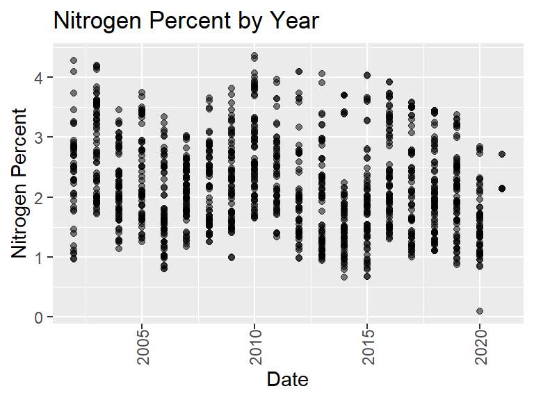

Figure 1

Lastly, a boxplot, see below (Fig 1.3) was used to visualize the relationship between sites and nitrogen concentration. Looking at this data, it appeared concentration amount was not too different by site. Looking at the scatter plot for year, it looked like nitrogen decreased slightly. This was then explored further in the Data Analysis section.

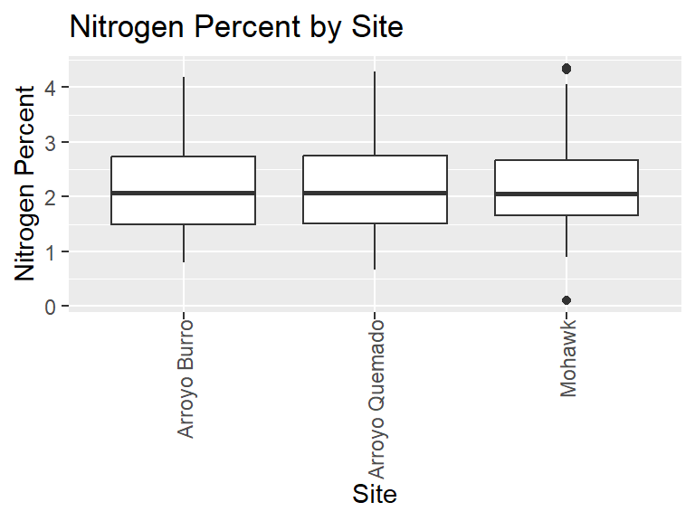

# Analysis

## Question 1: Does giant kelp nitrogen percent vary over year or season?

For the first question, we wanted to understand the relationship between nitrogen concentration and time. Linear regression and normal distribution tests were run for both the year and the specific date of collection. The boxplot (Fig 2.1) below shows the nitrogen concentrations over the years, starting with 2002.

H0 : There is no significant difference of nitrogen percent over the past twenty years. HA : There is significant difference of nitrogen percent over the past twenty years.

[output not shown]

[output cut: 515 more lines]

[output not shown]

```
##
##  Pearson's product-moment correlation
##
## data:  NitrogenYears$Nitrogen_Percent and NitrogenYears$Year
## t = -7.3858, df = 1280, p-value = 2.722e-13
## alternative hypothesis: true correlation is not equal to 0
## 95 percent confidence interval:
##  -0.2541137 -0.1490781
## sample estimates:
##        cor
## -0.2021772
```

```
##
## Call:
## lm(formula = NitrogenYears$Nitrogen_Percent ~ NitrogenYears$Date)
##
## Residuals:
##    Min     1Q Median     3Q    Max
## -0.965 -0.030  0.000  0.030  0.985
##
## Coefficients:
##                                Estimate Std. Error t value Pr(>|t|)
## (Intercept)                   2.800e+00  1.165e-01  24.033  < 2e-16 ***
## NitrogenYears$Date2002-05-10 -2.450e-01  1.648e-01  -1.487 0.137461
## NitrogenYears$Date2002-05-15  7.950e-01  1.648e-01   4.825 1.71e-06 ***
## NitrogenYears$Date2002-06-10 -1.020e+00  1.648e-01  -6.191 1.00e-09 ***
## NitrogenYears$Date2002-06-12  2.150e-01  1.648e-01   1.305 0.192348
## NitrogenYears$Date2002-06-13  1.385e+00  1.648e-01   8.406 2.23e-16 ***
## NitrogenYears$Date2002-07-10 -3.100e-01  1.648e-01  -1.881 0.060310 .
## NitrogenYears$Date2002-07-11 -1.735e+00  1.648e-01 -10.530  < 2e-16 ***
## NitrogenYears$Date2002-07-12 -6.750e-01  1.648e-01  -4.097 4.66e-05 ***
## NitrogenYears$Date2002-08-07 -9.150e-01  1.648e-01  -5.553 3.93e-08 ***
## NitrogenYears$Date2002-08-08 -7.400e-01  1.648e-01  -4.491 8.23e-06 ***
## NitrogenYears$Date2002-08-09  3.500e-02  1.648e-01   0.212 0.831838
## NitrogenYears$Date2002-09-04 -1.650e+00  1.648e-01 -10.014  < 2e-16 ***
## NitrogenYears$Date2002-09-05 -5.200e-01  1.648e-01  -3.156 0.001666 **
## NitrogenYears$Date2002-09-10 -3.050e-01  1.648e-01  -1.851 0.064560 .
## NitrogenYears$Date2002-10-09 -1.375e+00  1.648e-01  -8.345 3.57e-16 ***
## NitrogenYears$Date2002-10-10 -1.825e+00  1.648e-01 -11.076  < 2e-16 ***
## NitrogenYears$Date2002-10-11  5.000e-02  1.648e-01   0.303 0.761627
## NitrogenYears$Date2002-11-20  4.500e-01  1.648e-01   2.731 0.006465 **
## NitrogenYears$Date2002-11-21 -7.500e-02  1.648e-01  -0.455 0.649109
## NitrogenYears$Date2002-11-22  1.000e-01  1.648e-01   0.607 0.544095
## NitrogenYears$Date2002-12-06 -2.900e-01  1.648e-01  -1.760 0.078817 .
## NitrogenYears$Date2002-12-09 -5.050e-01  1.648e-01  -3.065 0.002258 **
## NitrogenYears$Date2002-12-10  2.000e-02  1.648e-01   0.121 0.903421
## NitrogenYears$Date2003-01-14 -2.200e-01  1.648e-01  -1.335 0.182222
## NitrogenYears$Date2003-01-16 -4.550e-01  1.427e-01  -3.189 0.001490 **
## NitrogenYears$Date2003-02-18 -8.475e-01  1.427e-01  -5.939 4.43e-09 ***
## NitrogenYears$Date2003-02-21 -9.950e-01  1.648e-01  -6.039 2.47e-09 ***
## NitrogenYears$Date2003-03-05 -6.250e-02  1.427e-01  -0.438 0.661512
## NitrogenYears$Date2003-03-06 -7.550e-01  1.648e-01  -4.582 5.41e-06 ***
```

[output cut: 515 more lines]

```
## NitrogenYears$Date2020-09-02 -1.353e+00  1.427e-01  -9.478  < 2e-16 ***
## NitrogenYears$Date2020-10-05 -1.483e+00  1.427e-01 -10.389  < 2e-16 ***
## NitrogenYears$Date2020-10-06 -1.095e+00  1.648e-01  -6.646 5.91e-11 ***
## NitrogenYears$Date2020-11-02 -1.715e+00  1.648e-01 -10.409  < 2e-16 ***
## NitrogenYears$Date2020-11-04 -1.200e+00  1.427e-01  -8.410  < 2e-16 ***
## NitrogenYears$Date2020-12-03 -7.050e-01  1.648e-01  -4.279 2.13e-05 ***
## NitrogenYears$Date2020-12-04 -9.200e-01  1.427e-01  -6.447 2.07e-10 ***
## NitrogenYears$Date2021-01-06 -6.550e-01  1.648e-01  -3.975 7.73e-05 ***
## NitrogenYears$Date2021-01-12 -3.725e-01  1.427e-01  -2.611 0.009227 **
## ---
## Signif. codes:  0 '***' 0.001 '**' 0.01 '*' 0.05 '.' 0.1 ' ' 1
##
## Residual standard error: 0.1648 on 728 degrees of freedom
## Multiple R-squared:  0.974,  Adjusted R-squared:  0.9542
## F-statistic: 49.28 on 553 and 728 DF,  p-value: < 2.2e-16
```

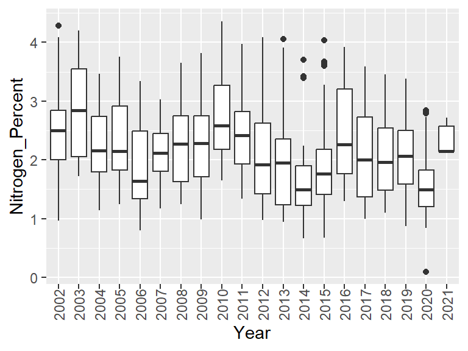

Below are the normal distribution residuals charts for the linear regression of change nitrogen by date.(Fig 2.2)

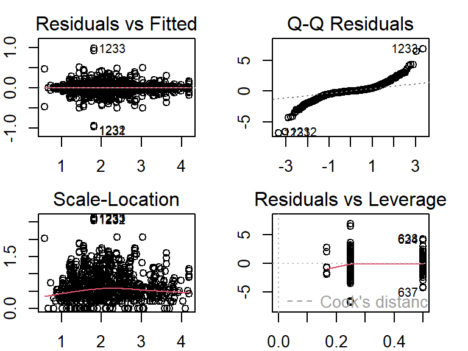

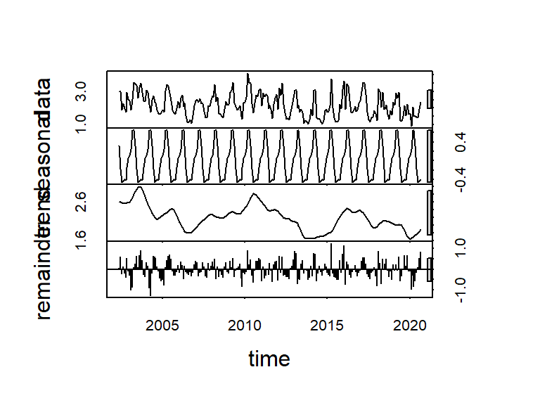

The Mann-Kendall analysis performed on the nitrogen concentration non-seasonal time series produced a tau value of -0.19 with a p-value of less than 0.05. As a result, the data displays a significant, decreasing trend for nitrogen concentration. The plot below displays the non-seasonal nitrogen concentration amount in the time series which was produced by removing the seasonal component from the time series (Fig 2.4).

```
## tau = -0.19, 2-sided pvalue =0.00011555
```

```
## Score =  -365 , Var(Score) = 8963
## denominator =  1925.499
## tau = -0.19, 2-sided pvalue =0.00011555
```

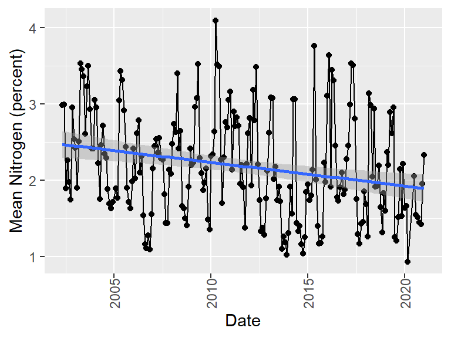

```
## tau = -0.188, 2-sided pvalue =3.0712e-05
```

```
## Score =  -4581 , Var(Score) = 1207396
## denominator =  24309.5
## tau = -0.188, 2-sided pvalue =3.0712e-05
```

## Question 2: Does giant kelp nitrogen concentration amount vary by season?

For the second question, we wanted to know the relationship between concentration and season.

H0 : There is no significant difference of nitrogen concentration by season. HA : There is significant difference of nitrogen concentration by season.

```
##
## Call:
## lm(formula = NitrogenYears$Nitrogen_Percent ~ NitrogenYears$SeasonNames)
##
## Residuals:
##      Min       1Q   Median       3Q      Max
## -2.64975 -0.49742 -0.05865  0.43835  2.19235
##
## Coefficients:
##                                 Estimate Std. Error t value Pr(>|t|)
## (Intercept)                      2.18584    0.03784  57.764   <2e-16 ***
## NitrogenYears$SeasonNamesSpring  0.56091    0.05430  10.330   <2e-16 ***
## NitrogenYears$SeasonNamesSummer -0.09819    0.05335  -1.840   0.0659 .
## NitrogenYears$SeasonNamesFall   -0.46618    0.05319  -8.765   <2e-16 ***
## ---
## Signif. codes:  0 '***' 0.001 '**' 0.01 '*' 0.05 '.' 0.1 ' ' 1
##
## Residual standard error: 0.679 on 1278 degrees of freedom
## Multiple R-squared:  0.2242, Adjusted R-squared:  0.2224
## F-statistic: 123.1 on 3 and 1278 DF,  p-value: < 2.2e-16
```

```
##
## Call:
## lm(formula = NitrogenYears$Nitrogen_Percent ~ NitrogenYears$Month)
##
## Residuals:
##      Min       1Q   Median       3Q      Max
## -2.31165 -0.46124 -0.03038  0.39800  1.90799
##
## Coefficients:
##                        Estimate Std. Error t value Pr(>|t|)
## (Intercept)             2.28433    0.06303  36.244  < 2e-16 ***
## NitrogenYears$MonthFeb -0.01367    0.08871  -0.154 0.877591
## NitrogenYears$MonthMar  0.12432    0.08871   1.401 0.161331
## NitrogenYears$MonthApr  0.63036    0.09097   6.929 6.71e-12 ***
## NitrogenYears$MonthMay  0.65573    0.08957   7.321 4.36e-13 ***
## NitrogenYears$MonthJun  0.31246    0.08957   3.488 0.000502 ***
## NitrogenYears$MonthJul -0.35232    0.08753  -4.025 6.03e-05 ***
## NitrogenYears$MonthAug -0.50472    0.08753  -5.766 1.02e-08 ***
## NitrogenYears$MonthSep -0.57061    0.08753  -6.519 1.02e-10 ***
## NitrogenYears$MonthOct -0.63423    0.08871  -7.149 1.47e-12 ***
## NitrogenYears$MonthNov -0.49290    0.08753  -5.631 2.20e-08 ***
## NitrogenYears$MonthDec -0.27022    0.08753  -3.087 0.002064 **
## ---
## Signif. codes:  0 '***' 0.001 '**' 0.01 '*' 0.05 '.' 0.1 ' ' 1
##
## Residual standard error: 0.6428 on 1270 degrees of freedom
## Multiple R-squared:  0.3093, Adjusted R-squared:  0.3033
## F-statistic: 51.69 on 11 and 1270 DF,  p-value: < 2.2e-16
```

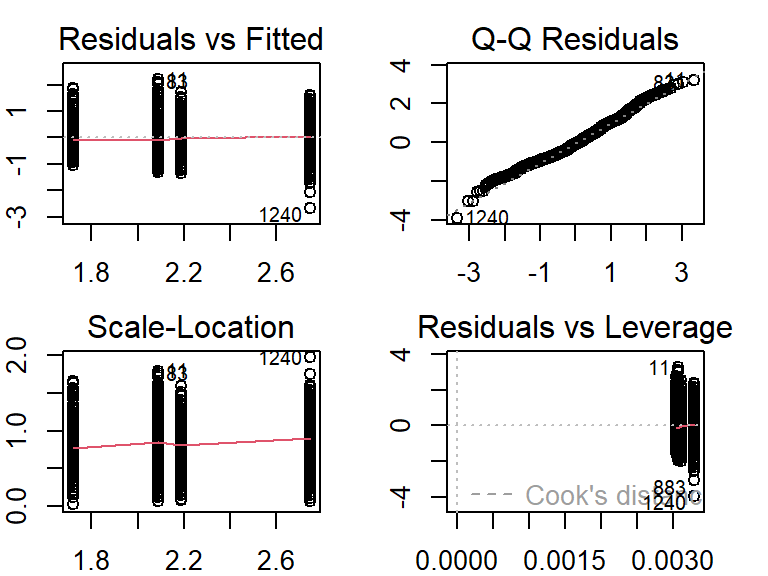

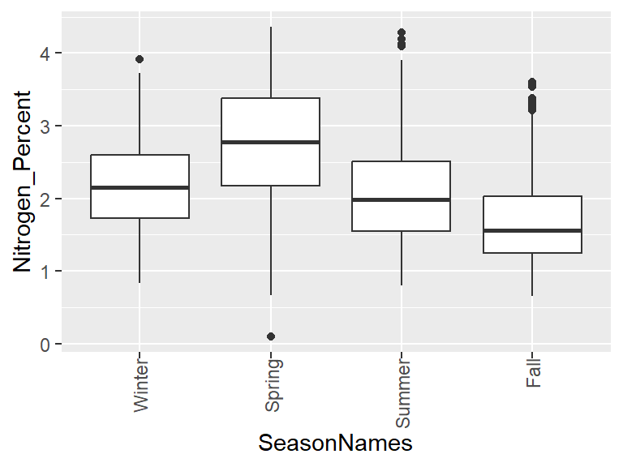

The last three questions focus on the experiment completed over five days in the spring and summer of 2019. Nitrogen was blasted for 45 minutes and data on nitrogen and biomass update was recorded.

The metadata indicates that the giant kelp blades studied were collected during the nitrate replete spring and the nitrate-deplete summer. The five replicate experiments were conducted in both spring and summer of 2019, which allows us to find potential differences in the nitrogen surge uptake of the two populations. The experimenters calculate uptake rate using a modified version of an equation by Legendre and Grosselin (1997) V= (nt - n0)/[t(ds-d0)] where nt is the atom percentage of Nitrogen-15 in the blade after incubation; n0 is the average concentration of isotope in the control blades; ds is the atom percentage of Nitrogen-15 in the seawater at the start of the incubation; d0 is the atom percentage of Nitrogen-15 in the nitrate pool before isotope tracer was added; and t is the length of the incubation time in minutes.

# Summary and Conclusions

Table 2: Significance Values

[output not shown]

# References

Cedeno, T., Brzezinski, M., Miller, R., Reed, D. (2021). Santa Barbara Coastal LTER: Reef: Surge uptake capability in Macrocystis pyrifera in response to pulses of three different forms of nitrogen ver 1. Environmental Data Initiative. https://doi.org/10.6073/pasta/d079ff0e95defb71b87040f56235d755

Conroy, G. (2023). Why Earth’s giant kelp forests are worth $500 billion a year. Nature. https://www.nature.com/articles/d41586-023-01307-3

Fernández, P.A., Gaitán-Espitia, J.D., Leal, P.P. et al. (2020). Nitrogen sufficiency enhances thermal tolerance in habitat-forming kelp: implications for acclimation under thermal stress. Scientific Reports 10, 3186.https://doi.org/10.1038/s41598-020-60104-4

Hurlimann, S. (2019, July 4). How kelp naturally combats global climate change. Science in the News.https://sitn.hms.harvard.edu/flash/2019/how-kelp-naturally-combats-global-climate-change/

Legendre, L., Gosselin, M., (1997). Estimation of N or C uptake rates by phytoplankton using 15N or 13C: revisiting the usual computation formulae. Journal of Plankton Research 19, Issue 2, Pages 263–271. https://academic.oup.com/plankt/article/19/2/263/1544362.

Wilson, S. (2019). Fires, floods and free parking: California’s unending fight against climate change. The Washington Post. https://www.washingtonpost.com/graphics/2019/national/climate-environment/climate-change-california/

Santa Barbara Coastal LTER, Reed, D., Miller, R. (2021). SBC LTER: Reef: Macrocystis pyrifera CHN content (carbon, hydrogen, nitrogen), ongoing since 2002 ver 21. Environmental Data Initiative. https://doi.org/10.6073/pasta/48686fef076a23310a0e48f69d76260c (Accessed 2023-12-05).